# Programming Assignment 4

```python
# import packages
import pandas as pd
import numpy as np
import requests
from pandas.io.json import json_normalize #special package in pandas
import json
import matplotlib.pyplot as plt
%matplotlib inline
```

```python
# set API key
apiKey = "2Ved520AQRPjEhVcLrjoCDl5FrEwTBTya86LmDoX"

# set  parameter
params = {'api_key': apiKey}
```

```python
food_list=["turkey", "macaroni and cheese", "mashed potatoes", "bread stuffing", "ham", "sweet potato souffle", "cranberry sauce", "mixed vegetables", "apple pie", "pecan pie"]
```

```python
# counter that allows us to see which food word is being processed in the loop
counter = 0

# for each food, pull nutritional value

# use for loop to create api call
for food in food_list:

    # increment counter for sequence of foods
    counter=counter+1

    # send API request - this should look familiar! From Module 8 - Web Scraping/APIs
    response = requests.post(
        r'https://api.nal.usda.gov/fdc/v1/search',
        params=params,
        json={'generalSearchInput': food}
    )

    # save to JSON
    item = response.json()

    # get total matches (there can be multiple hits for one food keyword, so we need to take the length of the match object to see how many matches we got)
    l = [i for i in range(len(item['foods']))]

    # for each match
    for i in l:
        # create df of food nutrients across all matches - this should look familiar! From Module 5 - Data Structures
        if i == 0: # for the first match, initialize the dataframe
            rdf = pd.json_normalize(item['foods'][i]['foodNutrients']) # convert json to data frame
        else: # for subsequent matches, create a dataframe (with a different name to be concatenated)
            df = pd.json_normalize(item['foods'][i]['foodNutrients'])
            rdf = pd.concat([rdf,df]) # concatenate dataframes - this should look familiar! From Module 4 - Data Wrangling

    # Now we have a dataframe with all the matches for a food word

    # recode variable values to simplify names
    rdf['nutrientName'].replace('Energy','Energy',inplace=True)
    rdf['nutrientName'].replace('Carbohydrate, by difference','Carbs',inplace=True)
    rdf['nutrientName'].replace('Protein','Protein',inplace=True)
    rdf['nutrientName'].replace('Fiber, total dietary','Fiber',inplace=True)
    rdf['nutrientName'].replace('Total lipid (fat)','Fat',inplace=True)
    rdf['nutrientName'].replace('Sodium, Na','Sodium',inplace=True)
    rdf['nutrientName'].replace('Fatty acids, total saturated','Sat_Fatty_Acids',inplace=True)
    rdf['nutrientName'].replace('Calcium, Ca','Calcium',inplace=True)
    rdf['nutrientName'].replace('Iron, Fe','Iron',inplace=True)
    rdf['nutrientName'].replace('Sugars, total including NLEA','Sugar',inplace=True)
    rdf['nutrientName'].replace('Cholesterol','Chol',inplace=True)
    rdf['nutrientName'].replace('Fatty acids, total trans','Trans_Fatty_Acids',inplace=True)
    rdf['nutrientName'].replace('Vitamin C, total ascorbic acid','VitaminC',inplace=True)
    rdf['nutrientName'].replace('Vitamin A, IU','VitaminA',inplace=True)
    rdf['nutrientName'].replace('Potassium, K','Potassium',inplace=True)
    rdf['nutrientName'].replace('Fatty acids, total polyunsaturated','Unsat_Fatty_Acids',inplace=True)

    # Since we have multiple matches for a food word, lets aggregate to one row per food match/nutrient by finding the average
    # nutrient value across all matches
    # find average nutrient
    agg_food = rdf[['nutrientName','value']].groupby(['nutrientName']).agg('mean')

    # reset index
    agg_food = agg_food.reset_index()

    # rename columns
    agg_food.columns = ["nutrientName","Value"]

    # subset data to only include the nutrients we want
    agg_food = agg_food[agg_food["nutrientName"].isin(['Energy','Carbs','Protein','Fiber','Fat'])]


    # set food name into a variable so we know what values each food is associated with
    agg_food["Food"] = food

    # transpose the data so the nutrient values are their own columns
    new=agg_food.pivot_table(index=["Food"], columns=['nutrientName'], values='Value')

    # reset the index
    new.reset_index(inplace=True)

    # append food match to a dataframe with all foods
    if counter ==1: # initialize the df
        all_foods=new
    else:
        all_foods=pd.concat([all_foods,new])
```

```python
# print dataframe
all_foods
```

| nutrientName | Food | Carbs | Energy | Fat | Fiber | Protein |
| --- | --- | --- | --- | --- | --- | --- |
| 0 | turkey | 6.864400 | 380.296875 | 11.239800 | 0.373913 | 17.017400 |
| 0 | macaroni and cheese | 20.900408 | 309.446154 | 6.498367 | 0.946939 | 6.663469 |
| 0 | mashed potatoes | 56.196000 | 296.920000 | 4.590612 | 4.112000 | 6.404000 |
| 0 | bread stuffing | 28.132600 | 375.338983 | 9.932400 | 2.300000 | 8.293800 |
| 0 | ham | 7.249200 | 244.160714 | 8.330400 | 0.328205 | 14.320200 |
| 0 | sweet potato souffle | 24.070000 | 226.725806 | 6.781600 | 2.642000 | 2.851200 |
| 0 | cranberry sauce | 28.553878 | 197.308824 | 0.239800 | 1.972917 | 1.543400 |
| 0 | mixed vegetables | 9.295800 | 47.489796 | 0.034043 | 2.110000 | 1.625000 |
| 0 | apple pie | 36.368000 | 267.440000 | 13.069600 | 2.134694 | 2.963400 |
| 0 | pecan pie | 43.926000 | 505.185185 | 24.123200 | 2.579592 | 4.574600 |

# Is there an association between the amount of protein and energy in a food?

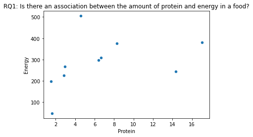

```python
# Create a scatterplot
all_foods.plot.scatter(x='Protein',y='Energy')

# Add axis labels
plt.xlabel("Protein")
plt.ylabel("Energy")

# add title
plt.title("RQ1: Is there an association between the amount of protein and energy in a food?")
```

There is concentration trend of increasing, but there are also some outliers in the trend.

# Which food is the most nutritious and the least nutritious?

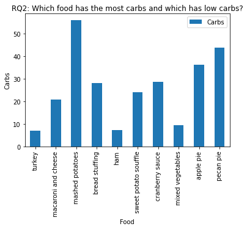

```python
# Create a scatterplot
all_foods.plot.bar(x='Food',y='Carbs')

# Add axis labels
plt.xlabel("Food")
plt.ylabel("Carbs")

# add title
plt.title("RQ2: Which food has the most carbs and which has low carbs?")
```

Mashed potatoes has the most carbs. Turkey and Ham has the least carbs.

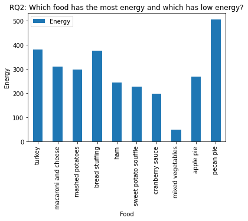

```python
#Which food is the most nutritious?
# Create a scatterplot
all_foods.plot.bar(x='Food',y='Energy')

# Add axis labels
plt.xlabel("Food")
plt.ylabel("Energy")

# add title
plt.title("RQ2: Which food has the most energy and which has low energy?")
```

Pecan Pie has the most energy. Mixed vegetable has the least energy.

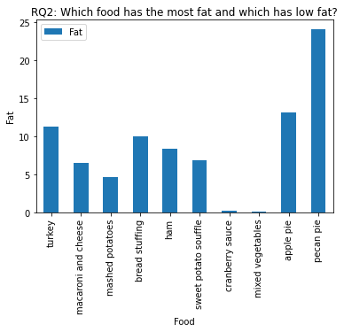

```python
#Which food is the most nutritious?
# Create a scatterplot
all_foods.plot.bar(x='Food',y='Fat')

# Add axis labels
plt.xlabel("Food")
plt.ylabel("Fat")

# add title
plt.title("RQ2: Which food has the most fat and which has low fat?")
```

Pecan pie has the most fat. Mixed vegetable has the least fat.

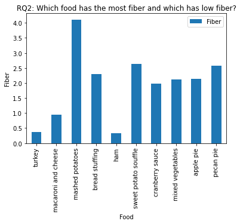

```python
#Which food is the most nutritious?
# Create a scatterplot
all_foods.plot.bar(x='Food',y='Fiber')

# Add axis labels
plt.xlabel("Food")
plt.ylabel("Fiber")

# add title
plt.title("RQ2: Which food has the most fiber and which has low fiber?")
```

Mashed potatoes has the most fiber. Ham and Turkey have the least fiber.

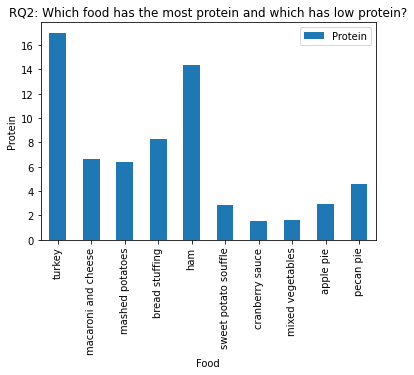

```python
#Which food is the most nutritious?
# Create a scatterplot
all_foods.plot.bar(x='Food',y='Protein')

# Add axis labels
plt.xlabel("Food")
plt.ylabel("Protein")

# add title
plt.title("RQ2: Which food has the most protein and which has low protein?")
```

Turkey has the most protein. Canberry sauce and Mixed vegetables have the least protein.

I would also consider macaroni and cheese is the least nutritious food despite the fact that its deliciousness. The reason is that its nutrient value doesn't stand out among all of the thanksgiving food.